# Differential Expression: By localisation

**What’s the difference between plasma cells in the lymphoid regions vs those in the lamina propria?**

ie. We expect there to be some difference in cell state of plasma cells depending on where they are.

- Niche 6 captures the lymphoid regions seen in in HC_a, full of T cells and plasma cells
- Niche 3 covered the non-epithelial regions in the lamina propria, and has a sizeable number of plasma cells also.

NB: We’re working with some very broad annotations, our ‘plasma’ cell group is really plasma and B cells!

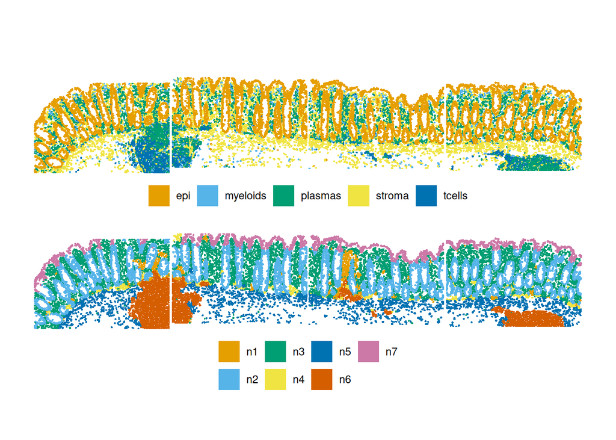

```r
p1 <- plotSpatialFeature(sfe.sample.HC, "celltype_subset",colGeometryName = "cellSeg") +
  theme(legend.title=element_blank()) +
  ggtitle(sample)

p2 <- plotSpatialFeature(sfe.sample.HC, "niche",colGeometryName = "cellSeg") +
  theme(legend.title=element_blank()) +
  ggtitle(sample)

p1 + p2 + plot_layout(nrow = 2) &
  theme(legend.position = "bottom")
```

Each niche has a different balance of cell types within it - and we can again see the sizeable proportion of plasma cells present in both n3 and n6.

```r
## Celltype proportions
celltype_summary_table<- colData(sfe) %>% as_tibble() %>%
  group_by(celltype_subset, niche ) %>%
  summarise(n_cells = n())
```

[output not shown]

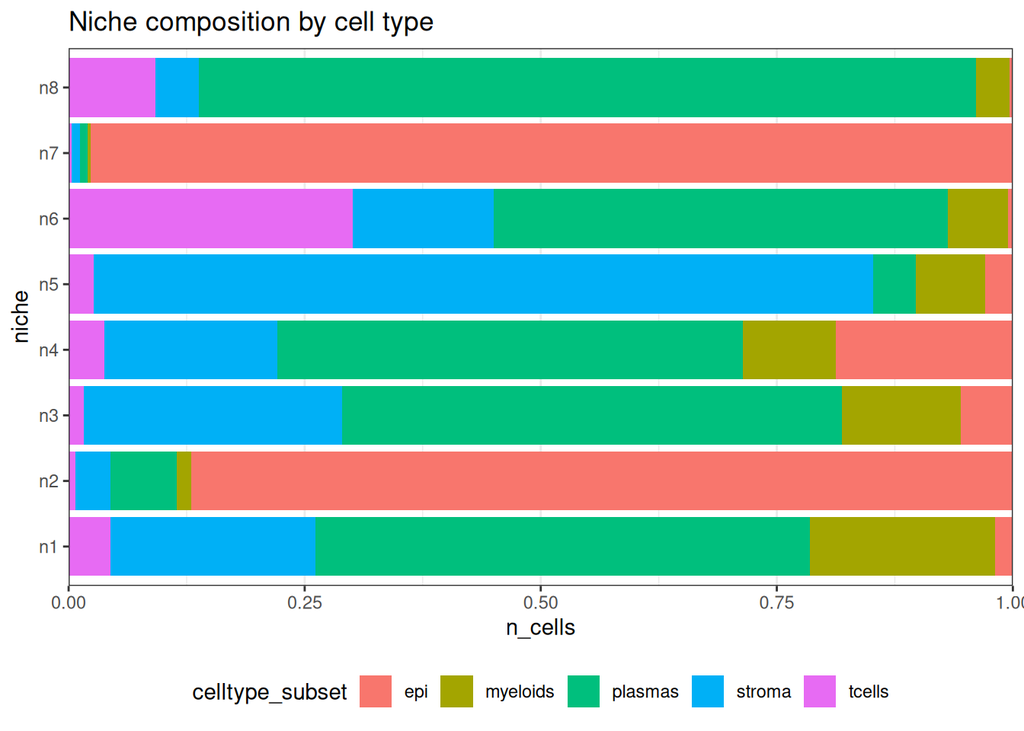

```r
ggplot(celltype_summary_table, aes(fill=celltype_subset, y=n_cells, x=niche) )+
  geom_bar(position="fill", stat="identity") +
  theme_bw() +
  coord_flip() +
  theme(legend.position = "bottom") +
  scale_y_continuous(expand = c(0,0)) +
  ggtitle( "Niche composition by cell type")
```

## Pool samples into pseudobulk

Once again, lets build (load) a pseudobulk representation to run a differential expression. This time, we will pool cells on the basis of sample, cell type and niche.

```r
# # DO NOT RUN
# sfe$pdb_sample <- paste0(sfe$tissue_sample, '_', sfe$niche,"_", sfe$celltype_subset)
# se.pdb <- aggregateAcrossCells(sfe, ids=sfe$pdb_sample,
#                                BPPARAM = MulticoreParam(workers=4)  )
```

Load pseudobulk

```r
se.pdb <- readRDS(spe_pseudobulk_by_celltype_in_niche_file)
```

```r
counts(se.pdb)[1:5,1:5]
```

```
##      CD_a_n1_epi CD_a_n1_myeloids CD_a_n1_plasmas CD_a_n1_stroma CD_a_n1_tcells
## AATK           4                2               9              7              0
## ABL1           9                2              14             21              0
## ABL2           4                1               4              7              3
## ACE            1                2               6              3              1
## ACE2           8                5              13              7              0
```

## Filter to a minimum number of cells per pool

```r
DT::datatable(data.frame(colData(se.pdb))[,c('pdb_sample','individual_code', 'niche', 'celltype_subset' ,'tissue_sample','ncells')])
```

|  | pdb_sample | individual_code | niche | celltype_subset | tissue_sample | ncells |
| --- | --- | --- | --- | --- | --- | --- |
| CD_a_n1_epi | CD_a_n1_epi | CD_a | n1 | epi | CD_a | 61 |
| CD_a_n1_myeloids | CD_a_n1_myeloids | CD_a | n1 | myeloids | CD_a | 39 |
| CD_a_n1_plasmas | CD_a_n1_plasmas | CD_a | n1 | plasmas | CD_a | 120 |
| CD_a_n1_stroma | CD_a_n1_stroma | CD_a | n1 | stroma | CD_a | 107 |
| CD_a_n1_tcells | CD_a_n1_tcells | CD_a | n1 | tcells | CD_a | 9 |
| CD_a_n2_epi | CD_a_n2_epi | CD_a | n2 | epi | CD_a | 1504 |
| CD_a_n2_myeloids | CD_a_n2_myeloids | CD_a | n2 | myeloids | CD_a | 45 |
| CD_a_n2_plasmas | CD_a_n2_plasmas | CD_a | n2 | plasmas | CD_a | 82 |
| CD_a_n2_stroma | CD_a_n2_stroma | CD_a | n2 | stroma | CD_a | 116 |
| CD_a_n2_tcells | CD_a_n2_tcells | CD_a | n2 | tcells | CD_a | 16 |

[output cut: 186 more lines]

With the extra level of separation - the pools (and thus total counts) are smaller.

We only care about plasma cells, and mostly only in n3 and n6 - so we can set a threshold accordingly. Here we choose 50 cells.

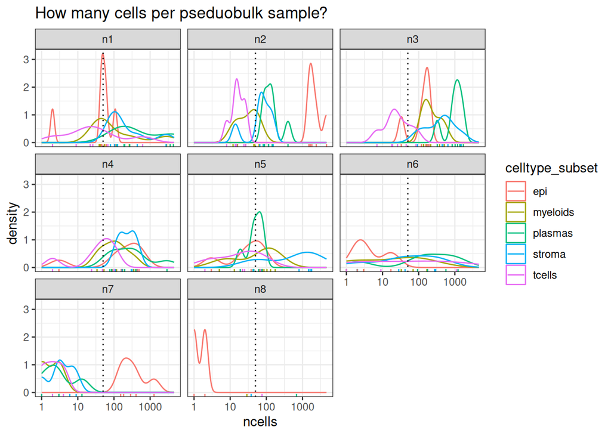

```r
# What is the minimum acceptable number of cells in a pool?
# Using a smaller threshold, we have smaller groups
min_cells_per_pdbsample <- 50

ggplot(colData(se.pdb), aes(x=ncells, col=celltype_subset)) +
  geom_density() +
  geom_vline(xintercept=min_cells_per_pdbsample, lty=3) +
  geom_rug() +
  scale_x_log10() +
  theme_bw() +
  ggtitle("How many cells per pseduobulk sample?") +
  facet_wrap(~niche)
```

Apply ncell filter, and also filter down to just plasma cells.

```r
# Filter on minimum number of cells per pdb group
# (ncells column was added by aggregateAcrossCells)
se.pdb <- se.pdb[,se.pdb$ncells >= min_cells_per_pdbsample]

se.pdb <- se.pdb[,se.pdb$celltype_subset == "plasmas"]
```